# Feed-microbiome-host interactions in Atlantic salmon over life stages

Low dosage of betamannan

Shashank Gupta

2023-02-03

## Step 1. Transcriptomics

### Load packages

```r
library("stringr")
library("dplyr")
library("DESeq2")
library("ggplot2")
library("tibble")
library("AnnotationHub")
library("AnnotationDbi")
library("readr")
library("dplyr")
library("clusterProfiler")
library("GenomicFeatures")
library("GO.db")
library("BiocParallel")
library("DT")
library("WGCNA")
library("cowplot")
library("gridExtra")
```

Set seed as a precaution for reproducibility as some methods are non-deterministic.

```r
set.seed(13118)
Run_analysis <- TRUE    # if FALSE it tries to load data instead of running the module creation step.
prefix <- "h"
save_TOM <- FALSE       # Can get rather big
pam_stage <- FALSE      # Partitioning around medoids, tries to put more genes into modules where it is not directly clear from the dendrogram cutting.
set_verbose = 1         # How much detail from the WGCNA functions? A higher number means more detail.
assoc_measure = "bicor"
plot_labeling_size = 15
theme_set(theme_bw())
```

### Import data

```r
host_gut_rawCounts_total1 <- read.table("/Users/shashankgupta/Desktop/ImprovAFish/host_data/host_gut_count.txt")
sample_info <- read.csv("/Users/shashankgupta/Desktop/ImprovAFish/ImprovAFish/sample_info.csv", row.names = 1)
omics_data_host <- host_gut_rawCounts_total1
host_gut_mapping_file <- sample_info
```

### Initial formatting

Main idea of this chunk of code is make sure we have same number of samples in `countData` and samples in `colData` for `DESeq2`. Also the order of the samples in `colData` need to match the order of the samples in `countData`

```r
#sample_info$New_Diet <- tolower(sample_info$New_Diet)
#Rename the sample names based on new diet
sample_info$ID_New <- paste(sample_info$Time, "_",
                            sample_info$New_Diet, "_",
                            sample_info$Tank_number, "_", "0",
                            sample_info$Sample_Number,
                                      sep = "")
head_change <- subset(sample_info, select=c("common" ,"ID_New"))
row.names(sample_info) <- sample_info$ID_New

omics_data_host1 <- omics_data_host[, colnames(omics_data_host) %in% sample_info$ID_New]
omics_data_host <- omics_data_host1
all(colnames(omics_data_host) == sample_info$ID_New)
```

```
## [1] FALSE
```

```r
# rename colnames of omics_data_host using new ID
df1 <- subset(sample_info, select= c("common", "ID_New"))
omics_data_host %>%
  rename_with(~deframe(df1)[.x], .cols = df1$ID_New) %>%
  select(any_of(df1$ID_New)) -> omics_data_host_new
omics_data_host <- omics_data_host_new

all(colnames(omics_data_host) == sample_info$ID_New)
```

```
## [1] TRUE
```

```r
reorder_idx <- match(sample_info$ID_New, colnames(omics_data_host))
omics_data_host <- omics_data_host[ , reorder_idx]
all(colnames(omics_data_host) %in% sample_info$ID_New)
```

```
## [1] TRUE
```

```r
all(colnames(omics_data_host) == sample_info$ID_New)
```

```
## [1] TRUE
```

### DESeq2 analysis

```r
df <- round(omics_data_host) %>%
  # The next steps require a data frame and round() returns a matrix
  as.data.frame() %>%
  # Only keep rows that have total counts above the cutoff
  dplyr::filter(rowSums(.) >= 50)

all(colnames(df) == rownames(sample_info))
```

```
## [1] TRUE
```

```r
dds <- DESeqDataSetFromMatrix(
  countData = df, # Our prepped data frame with counts
  colData = sample_info, # Data frame with annotation for our samples
  design = ~1 # Here we are not specifying a model
)
```

```r
dds$group <- factor(paste0(dds$Time, dds$New_Diet))
design(dds) <- ~ group-1

dds <- DESeq(dds, parallel = T)
resultsNames(dds)
```

```
##  [1] "groupT1CTR" "groupT1MC1" "groupT1MC2" "groupT1MN3" "groupT2CTR"
##  [6] "groupT2MC1" "groupT2MC2" "groupT2MN3" "groupT3CTR" "groupT3MC1"
## [11] "groupT3MC2" "groupT3MN3"
```

```r
annot_function <- read_tsv("/Users/shashankgupta/Desktop/ImprovAFish/Salmo_salar-GCA_905237065.2_gene_annotations.tsv")
annot_function <- annot_function[, c("gene_id", "v2.gene_id.NCBI","v2.gene_name.ensembl", "v2.product")]
```

#### Time point 1 (T1)

##### Diet 1

```r
res <- results(dds,
               contrast = list("groupT1MC1","groupT1CTR"))
table(res$padj < 0.05)
```

```
##
## FALSE  TRUE
## 30430    12
```

```r
res_tbl <- as_tibble(res, rownames = "ENSEMBL") %>%
  filter(padj <0.05)%>%
  arrange(padj)

res_tbl <- merge(res_tbl, annot_function, by.x = "ENSEMBL", by.y = "gene_id", all.x = TRUE )
DT::datatable(res_tbl)
```

|  | ENSEMBL | baseMean | log2FoldChange | lfcSE | stat | pvalue | padj | v2.gene_id.NCBI | v2.gene_name.ensembl | v2.product |
| --- | --- | --- | --- | --- | --- | --- | --- | --- | --- | --- |
| 1 | ENSSSAG00000040735 | 55.6328183119782 | -2.46251388503369 | 0.568508048567351 | -4.33153741840465 | 1.48071776838437e-05 | 0.0409781911865063 | 100136447 | CLC4E | C type lectin receptor B isoform X1 |
| 2 | ENSSSAG00000041844 | 10.8189222270688 | 23.1830330026369 | 2.58985670669887 | 8.951473238914 | 3.50769153541234e-19 | 1.06781145721022e-14 | 106609937 | mtnr1aa | melatonin receptor type 1A-A-like |
| 3 | ENSSSAG00000053226 | 111.108970442405 | -2.66867317480632 | 0.543695664923732 | -4.90839516842694 | 9.18246901656903e-07 | 0.00465887869670657 | 106560548 | aspm | abnormal spindle-like microcephaly-associated protein homolog |
| 4 | ENSSSAG00000054480 | 9.12657467031003 | 4.51753748254977 | 1.05643789887183 | 4.276197860162 | 1.90112273116959e-05 | 0.0482283151518871 | 106565309 |  | acidic mammalian chitinase-like |
| 5 | ENSSSAG00000072878 | 7.3829253904581 | -1.90612486209477 | 0.398797421228124 | -4.77968201555749 | 1.75572660094739e-06 | 0.00680778545932093 | 106563427 | dlg4a | disks large homolog 4-like isoform X8 |
| 6 | ENSSSAG00000082411 | 37.5623436574197 | 5.24297219122999 | 1.09779767853886 | 4.77590023528583 | 1.78905077440929e-06 | 0.00680778545932093 | 106596459 |  | uncharacterized protein LOC106596459 |
| 7 | ENSSSAG00000084735 | 67.4605246295455 | -1.48752321413859 | 0.339447182991337 | -4.38219342705975 | 1.17490426581565e-05 | 0.0357664356599601 | 106569442 |  | zinc-binding protein A33-like |
| 8 | ENSSSAG00000091466 | 31.002495588602 | -2.73052935533781 | 0.393647240663811 | -6.93648798536804 | 4.01967416039387e-12 | 6.1183460395355e-08 | 106594032 |  | haptoglobin-like |
| 9 | ENSSSAG00000100845 | 43.4189531268155 | 2.22148293846609 | 0.42049845368918 | 5.28297528558367 | 1.27102543654747e-07 | 0.000967313908484452 | 106605285 | paqr6 | progestin and adipoQ receptor family member 6-like |
| 10 | ENSSSAG00000106741 | 10.3447687779567 | -3.841599752393 | 0.770690148954574 | -4.98462288327424 | 6.20827797496145e-07 | 0.00377984796227553 | 106613892 | bend5 | cytosolic carboxypeptidase 6-like isoform X2 |

[output cut: 2 more lines]

```r
# res_tbl %>%
#   filter(log2FoldChange > 0) %>%
#   select(v2.product)
# length(res_tbl$log2FoldChange[res_tbl$log2FoldChange>0]) # count positive elements
# length(res_tbl$log2FoldChange[res_tbl$log2FoldChange<0]) # count negative elements
```

##### Diet 2

```r
res <- results(dds,
               contrast = list("groupT1MC2","groupT1CTR"))
table(res$padj < 0.05)
```

```
##
## FALSE  TRUE
## 36872     5
```

```r
res_tbl <- as_tibble(res, rownames = "ENSEMBL") %>%
  filter(padj <0.05)%>%
  arrange(padj)
res_tbl <- merge(res_tbl, annot_function, by.x = "ENSEMBL", by.y = "gene_id", all.x = TRUE )
DT::datatable(res_tbl)
```

|  | ENSEMBL | baseMean | log2FoldChange | lfcSE | stat | pvalue | padj | v2.gene_id.NCBI | v2.gene_name.ensembl | v2.product |
| --- | --- | --- | --- | --- | --- | --- | --- | --- | --- | --- |
| 1 | ENSSSAG00000041844 | 10.8189222270688 | 21.5919015153746 | 2.59214259796 | 8.32975065969262 | 8.10127963691941e-17 | 2.98750889170677e-12 | 106609937 | mtnr1aa | melatonin receptor type 1A-A-like |
| 2 | ENSSSAG00000091466 | 31.002495588602 | -2.48041036989712 | 0.390297406528105 | -6.35518025077757 | 2.08182359935033e-10 | 3.8385704436621e-06 | 106594032 |  | haptoglobin-like |
| 3 | ENSSSAG00000098604 | 15.3120657881964 | 3.26054192086633 | 0.603414071396625 | 5.40349003350168 | 6.5356588743478e-08 | 0.000803384974364412 | 106589479 | CDR2L | cerebellar degeneration-related protein 2-like isoform X1 |
| 4 | ENSSSAG00000106741 | 10.3447687779567 | -3.57877952661635 | 0.759752437431337 | -4.71045481435495 | 2.47164595774124e-06 | 0.0182293775967248 | 106613892 | bend5 | cytosolic carboxypeptidase 6-like isoform X2 |
| 5 | ENSSSAG00000117100 | 33.3314864610604 | -1.76888322109349 | 0.360687504148707 | -4.90419878911081 | 9.3809450373503e-07 | 0.00864852775355917 | 106576185 |  | hemagglutinin/amebocyte aggregation factor-like isoform X1 |

```r
# res_tbl %>%
#   filter(log2FoldChange > 0) %>%
#   select(v2.product)
#
# length(res_tbl$log2FoldChange[res_tbl$log2FoldChange>0]) # count positive elements
# length(res_tbl$log2FoldChange[res_tbl$log2FoldChange<0]) # count negative elements
```

##### Diet 3

```r
res <- results(dds,
               contrast = list("groupT1MN3","groupT1CTR"))
table(res$padj < 0.05)
```

```
##
## FALSE  TRUE
## 36870     7
```

```r
res_tbl <- as_tibble(res, rownames = "ENSEMBL") %>%
  filter(padj <0.05)%>%
  arrange(padj)
res_tbl <- merge(res_tbl, annot_function, by.x = "ENSEMBL", by.y = "gene_id", all.x = TRUE )
DT::datatable(res_tbl)
```

|  | ENSEMBL | baseMean | log2FoldChange | lfcSE | stat | pvalue | padj | v2.gene_id.NCBI | v2.gene_name.ensembl | v2.product |
| --- | --- | --- | --- | --- | --- | --- | --- | --- | --- | --- |
| 1 | ENSSSAG00000041844 | 10.8189222270688 | 22.8555807061636 | 2.59000624941058 | 8.82452724249793 | 1.09923174154036e-18 | 4.0536368932784e-14 | 106609937 | mtnr1aa | melatonin receptor type 1A-A-like |
| 2 | ENSSSAG00000091466 | 31.002495588602 | -2.34948711747472 | 0.39010192579919 | -6.02275190685459 | 1.71476186249584e-09 | 2.10784244010863e-05 | 106594032 |  | haptoglobin-like |
| 3 | ENSSSAG00000105866 | 12.8622161992352 | 4.07780389079334 | 0.817665829296154 | 4.98712768063637 | 6.1283566902053e-07 | 0.00451990819329402 | 106586456 |  | titin-like isoform X9 |
| 4 | ENSSSAG00000106525 | 8.69605089693808 | -22.8667719253578 | 3.37626138408893 | -6.77280853701682 | 1.26306059481796e-11 | 2.3288942777551e-07 |  |  |  |
| 5 | ENSSSAG00000106741 | 10.3447687779567 | -3.74210286668745 | 0.765618631793399 | -4.88768521466344 | 1.02028493433813e-06 | 0.00627084125393123 | 106613892 | bend5 | cytosolic carboxypeptidase 6-like isoform X2 |
| 6 | ENSSSAG00000115953 | 54.0111253852231 | -2.56015495136803 | 0.473663207883663 | -5.4050112163173 | 6.48043375541988e-08 | 0.000597447388996548 | 106611589 | LECT2 | leukocyte cell-derived chemotaxin-2-like isoform X1 |
| 7 | ENSSSAG00000121341 | 5.79380715195045 | 3.4295153902018 | 0.722008563861721 | 4.74996497528888 | 2.0345188285255e-06 | 0.0107181358342192 | 106603753 |  | protein NLRC3-like |

```r
# res_tbl %>%
#   filter(log2FoldChange > 0) %>%
#   select(v2.product)
#
# length(res_tbl$log2FoldChange[res_tbl$log2FoldChange>0]) # count positive elements
# length(res_tbl$log2FoldChange[res_tbl$log2FoldChange<0]) # count negative elements
```

#### Time point 2 (T2)

##### Diet 1

```r
# T2
res <- results(dds,
               contrast = list("groupT2MC1","groupT2CTR"))
table(res$padj < 0.05)
```

```
##
## FALSE  TRUE
## 36872     5
```

```r
res_tbl <- as_tibble(res, rownames = "ENSEMBL") %>%
  filter(padj <0.05)%>%
  arrange(padj)
DT::datatable(res_tbl)
```

|  | ENSEMBL | baseMean | log2FoldChange | lfcSE | stat | pvalue | padj |
| --- | --- | --- | --- | --- | --- | --- | --- |
| 1 | ENSSSAG00000112004 | 3.01304042128169 | -17.8682355608544 | 1.48505239510302 | -12.0320573333138 | 2.41077498489499e-33 | 8.89021491179726e-29 |
| 2 | ENSSSAG00000118174 | 14.2300585399881 | -22.4621016221878 | 1.91478278098268 | -11.7308876209238 | 8.8525442101598e-32 | 1.63227636419031e-27 |
| 3 | ENSSSAG00000051829 | 3.25187052742412 | -17.3344574622404 | 3.12797453325863 | -5.54175146821988 | 2.99461133513215e-08 | 0.000368107607352228 |
| 4 | ENSSSAG00000085630 | 75.5452439421156 | -4.49614474983678 | 0.957494547616766 | -4.69573927186095 | 2.65644206582728e-06 | 0.0244904035153782 |
| 5 | ENSSSAG00000076570 | 7.46977925647747 | 3.24783514936467 | 0.713873910588759 | 4.54959216353216 | 5.37499886621939e-06 | 0.0396427666379145 |

```r
#
# length(res_tbl$log2FoldChange[res_tbl$log2FoldChange>0]) # count positive elements
# length(res_tbl$log2FoldChange[res_tbl$log2FoldChange<0]) # count negative elements
```

##### Diet 2

```r
res <- results(dds,
               contrast = list("groupT2MC2","groupT2CTR"))
table(res$padj < 0.05)
```

```
##
## FALSE  TRUE
## 36875     2
```

```r
res_tbl <- as_tibble(res, rownames = "ENSEMBL") %>%
  filter(padj <0.05)%>%
  arrange(padj)
DT::datatable(res_tbl)
```

|  | ENSEMBL | baseMean | log2FoldChange | lfcSE | stat | pvalue | padj |
| --- | --- | --- | --- | --- | --- | --- | --- |
| 1 | ENSSSAG00000051829 | 3.25187052742412 | -17.2227468113482 | 3.19829828055781 | -5.38497203842552 | 7.24559112844693e-08 | 0.00267195664043737 |
| 2 | ENSSSAG00000043044 | 169.469123402893 | 1.0636863338795 | 0.224260276264536 | 4.74308848449281 | 2.10484275491344e-06 | 0.0388101431364714 |

```r
#
# length(res_tbl$log2FoldChange[res_tbl$log2FoldChange>0]) # count positive elements
# length(res_tbl$log2FoldChange[res_tbl$log2FoldChange<0]) # count negative elements
```

##### Diet 3

```r
res <- results(dds,
               contrast = list("groupT2MN3","groupT2CTR"))
table(res$padj < 0.05)
```

```
##
## FALSE  TRUE
## 36876     1
```

```r
res_tbl <- as_tibble(res, rownames = "ENSEMBL") %>%
  filter(padj <0.05)%>%
  arrange(padj)
DT::datatable(res_tbl)
```

|  | ENSEMBL | baseMean | log2FoldChange | lfcSE | stat | pvalue | padj |
| --- | --- | --- | --- | --- | --- | --- | --- |
| 1 | ENSSSAG00000118800 | 11.4937789799458 | -23.4590551160183 | 4.75328282258742 | -4.93533753231382 | 8.0012262616406e-07 | 0.0295061220850521 |

```r
#
# length(res_tbl$log2FoldChange[res_tbl$log2FoldChange>0]) # count positive elements
# length(res_tbl$log2FoldChange[res_tbl$log2FoldChange<0]) # count negative elements
```

#### Time point 3 (T3)

##### Diet 1

```r
res <- results(dds,
               contrast = list("groupT3MC1","groupT3CTR"))
table(res$padj < 0.05)
```

```
##
## FALSE  TRUE
## 36873     4
```

```r
res_tbl <- as_tibble(res, rownames = "ENSEMBL") %>%
  filter(padj <0.05)%>%
  arrange(padj)

res_tbl <- merge(res_tbl, annot_function, by.x = "ENSEMBL", by.y = "gene_id", all.x = TRUE )
DT::datatable(res_tbl)
```

|  | ENSEMBL | baseMean | log2FoldChange | lfcSE | stat | pvalue | padj | v2.gene_id.NCBI | v2.gene_name.ensembl | v2.product |
| --- | --- | --- | --- | --- | --- | --- | --- | --- | --- | --- |
| 1 | ENSSSAG00000039276 | 11.1919662331063 | 17.5417866186208 | 1.80340796025133 | 9.72702073255579 | 2.31267167864532e-22 | 8.52843934934036e-18 | 100136478 |  | alpha amylase precursor |
| 2 | ENSSSAG00000051829 | 3.25187052742412 | -14.6275183016499 | 3.19882952860605 | -4.57277206266885 | 4.81313652078442e-06 | 0.0443735088692418 | 100195850 | cbpa2 | Carboxypeptidase A2 precursor |
| 3 | ENSSSAG00000115661 | 10.6333055325222 | 14.8723270710524 | 2.11503441036878 | 7.0317187267224 | 2.04004743834776e-12 | 2.50769431279835e-08 | 106577462 |  | trypsin-like |
| 4 | ENSSSAG00000118174 | 14.2300585399881 | 16.5077681399464 | 2.04417045501199 | 8.0755340629603 | 6.71819495461447e-16 | 1.23873437670659e-11 | 100137023 |  | trypsin-2 |

```r
# res_tbl %>%
#   filter(log2FoldChange > 0) %>%
#   select(v2.product)
#
# length(res_tbl$log2FoldChange[res_tbl$log2FoldChange>0]) # count positive elements
# length(res_tbl$log2FoldChange[res_tbl$log2FoldChange<0]) # count negative elements
```

##### Diet 2

```r
res <- results(dds,
               contrast = list("groupT3MC2","groupT3CTR"))
table(res$padj < 0.05)
```

```
##
## FALSE  TRUE
## 36135    27
```

```r
res_tbl <- as_tibble(res, rownames = "ENSEMBL") %>%
  filter(padj <0.05)%>%
  arrange(padj)

res_tbl <- merge(res_tbl, annot_function, by.x = "ENSEMBL", by.y = "gene_id", all.x = TRUE )
DT::datatable(res_tbl)
```

|  | ENSEMBL | baseMean | log2FoldChange | lfcSE | stat | pvalue | padj | v2.gene_id.NCBI | v2.gene_name.ensembl | v2.product |
| --- | --- | --- | --- | --- | --- | --- | --- | --- | --- | --- |
| 1 | ENSSSAG00000003934 | 81.7705072371768 | 1.69210963914262 | 0.342775878441014 | 4.93648983364448 | 7.95411817167276e-07 | 0.00394506607616251 | 106610539 |  | interferon-induced very large GTPase 1-like |
| 2 | ENSSSAG00000004392 | 3.69946998616148 | 3.854181278513 | 0.815805780072144 | 4.72438584361607 | 2.30811824719136e-06 | 0.00834661720549338 | 106599566 | LBH | protein LBH-like |
| 3 | ENSSSAG00000008181 | 18.7718643671088 | 3.14712234914271 | 0.67200541052263 | 4.68318007543294 | 2.82458162150814e-06 | 0.00928568369063432 | 106569065 | lamc2 | laminin subunit gamma-2-like isoform X2 |
| 4 | ENSSSAG00000009522 | 23.4156814710556 | 1.01764217754741 | 0.240295013202816 | 4.23497002282143 | 2.28582197027343e-05 | 0.0413299470445139 | 106591935 | fkbpl | FK506-binding protein-like |
| 5 | ENSSSAG00000028144 | 8.39906266415533 | 3.76572259883452 | 0.818813512319936 | 4.59899909097144 | 4.2452563469551e-06 | 0.0118089969245069 | 106583477 |  | laminin subunit beta-3 |
| 6 | ENSSSAG00000040235 | 22.6845669714963 | 1.29359996669475 | 0.263014865306622 | 4.91835305653417 | 8.72753957449812e-07 | 0.00394506607616251 | 106560677 |  | capZ-interacting protein-like isoform X2 |
| 7 | ENSSSAG00000042532 | 14.2391772233454 | -17.0258299965051 | 2.00323011172271 | -8.49918833431644 | 1.90920930414444e-17 | 2.30136089521571e-13 | 106560589 | fetub | histidine-rich glycoprotein-like |
| 8 | ENSSSAG00000042547 | 10.2887648327621 | 16.3396327009171 | 2.02565585757371 | 8.06634189110896 | 7.24357834391726e-16 | 6.5485570018184e-12 | 106560590 | si:ch211-284e20.8 | fetuin-B-like isoform X2 |
| 9 | ENSSSAG00000044611 | 2.90247723438128 | 2.44047329303057 | 0.591397677270597 | 4.12661967881541 | 3.68134461085284e-05 | 0.0499178551669084 | 106587081 | RYR3 | ryanodine receptor 3-like isoform X7 |
| 10 | ENSSSAG00000047130 | 14.9044493456632 | 1.25187479987087 | 0.27976127937045 | 4.47479652183454 | 7.64841152303038e-06 | 0.0187578636637178 | 106604936 | fam13b | protein FAM13B-like isoform X1 |

[output cut: 17 more lines]

```r
# res_tbl %>%
#   filter(log2FoldChange > 0) %>%
#   select(v2.product)
#
# length(res_tbl$log2FoldChange[res_tbl$log2FoldChange>0]) # count positive elements
# length(res_tbl$log2FoldChange[res_tbl$log2FoldChange<0]) # count negative elements
```

##### Diet 3

```r
res <- results(dds,
               contrast = list("groupT3MN3","groupT3CTR"))
table(res$padj < 0.05)
```

```
##
## FALSE  TRUE
## 36870     7
```

```r
res_tbl <- as_tibble(res, rownames = "ENSEMBL") %>%
  filter(padj <0.05)%>%
  arrange(padj)
res_tbl <- merge(res_tbl, annot_function, by.x = "ENSEMBL", by.y = "gene_id", all.x = TRUE )
DT::datatable(res_tbl)
```

|  | ENSEMBL | baseMean | log2FoldChange | lfcSE | stat | pvalue | padj | v2.gene_id.NCBI | v2.gene_name.ensembl | v2.product |
| --- | --- | --- | --- | --- | --- | --- | --- | --- | --- | --- |
| 1 | ENSSSAG00000039276 | 11.1919662331063 | 14.9611008039498 | 1.78025434444928 | 8.4039119750487 | 4.31846438041697e-17 | 7.96260054783184e-13 | 100136478 |  | alpha amylase precursor |
| 2 | ENSSSAG00000041844 | 10.8189222270688 | -21.3193038149362 | 2.5928418938905 | -8.22236938749362 | 1.99521543247702e-16 | 2.45258531678183e-12 | 106609937 | mtnr1aa | melatonin receptor type 1A-A-like |
| 3 | ENSSSAG00000100678 | 15.9435854605738 | 2.13698577401633 | 0.478581361884365 | 4.4652507268611 | 7.99750384152565e-06 | 0.0421319927377059 | 106596905 |  | myosin heavy chain, fast skeletal muscle-like isoform X1 |
| 4 | ENSSSAG00000102667 | 26.2429122436899 | 3.46933710331619 | 0.747296874965998 | 4.64251520317685 | 3.44193303536119e-06 | 0.0211546940908357 | 106603496 | tbx16l | T-box transcription factor TBX6L-like isoform X3 |
| 5 | ENSSSAG00000115661 | 10.6333055325222 | 15.9821285010122 | 2.06854467039058 | 7.72626703681213 | 1.10746188986564e-14 | 1.02099680281438e-10 | 106577462 |  | trypsin-like |
| 6 | ENSSSAG00000118174 | 14.2300585399881 | 18.359284634837 | 1.97178102293245 | 9.31101599077817 | 1.26615319540787e-20 | 4.66919313870561e-16 | 100137023 |  | trypsin-2 |
| 7 | ENSSSAG00000118637 | 356.609016145421 | -8.67340466352024 | 1.81071977029873 | -4.79003145919665 | 1.66755167082222e-06 | 0.0122988605929822 | 106603810 | atp5mf | ATP synthase subunit f, mitochondrial |

```r
# res_tbl %>%
#   filter(log2FoldChange > 0) %>%
#   select(v2.product)
#
# length(res_tbl$log2FoldChange[res_tbl$log2FoldChange>0]) # count positive elements
# length(res_tbl$log2FoldChange[res_tbl$log2FoldChange<0]) # count negative elements
```

```r
# loop
# Create the dataframe
df <- data.frame(Group=character(), a1=character(), a2=character(), a3=character())

# Loop through each group and store the results in the dataframe
for(treatment in c("T1", "T2", "T3")){
  for(group in c("MC1","MC2","MN3")){
    sample_name <- paste0("group",treatment,group)
    CTR_sample <- paste0("group",treatment,"CTR")

    # Calculate results
    res <- results(dds, contrast = list(sample_name,CTR_sample))

    # Filter the results and count the number of positive elements
    res_tbl <- as_tibble(res, rownames = "ENSEMBL") %>%
      filter(padj <0.05)%>%
      arrange(padj)
    a <- length(res_tbl$log2FoldChange[res_tbl$log2FoldChange>0])

    # Store the results in the dataframe
    df <- rbind(df, c(sample_name,a))
  }
}
names(df) <- c("Groups", "DEGs (up-regulated)")
df
```

```
##       Groups DEGs (up-regulated)
## 1 groupT1MC1                   4
## 2 groupT1MC2                   2
## 3 groupT1MN3                   3
## 4 groupT2MC1                   1
## 5 groupT2MC2                   1
## 6 groupT2MN3                   0
## 7 groupT3MC1                   3
## 8 groupT3MC2                  24
## 9 groupT3MN3                   5
```

## Step 2. Host-microbiome interactions

### WGCNA analysis

```r
omics_data_host <- t(assay(vst(dds)))
dim(omics_data_host) %>% paste(c("Samples", "Genes"))
```

```
## [1] "142 Samples" "36878 Genes"
```

```r
powers <- c(c(1:10), seq(from = 12, to=20, by=2))
sft <- pickSoftThreshold(omics_data_host,
                         powerVector = powers,
                         verbose = set_verbose,
                         networkType = "signed",
                         corFn= "bicor")
```

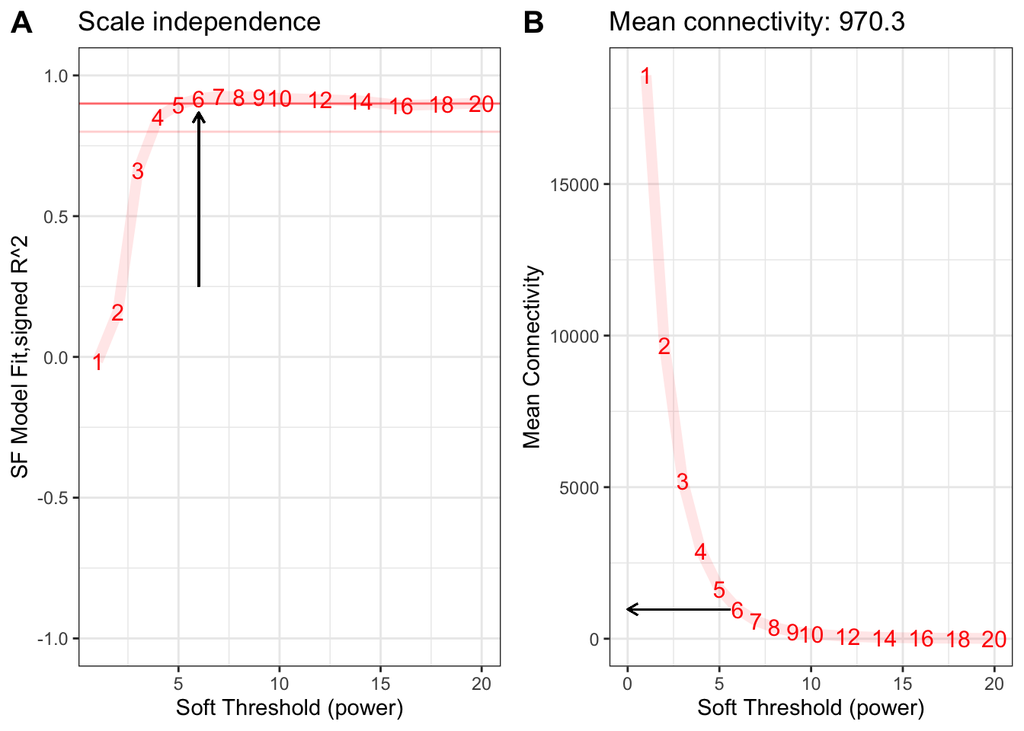

```r
idx <- min(which((-sign(sft$fitIndices[,3])*sft$fitIndices[,2]) > 0.90))
if(is.infinite(idx)){
  idx <- min(which((-sign(sft$fitIndices[,3])*sft$fitIndices[,2]) > 0.80))
  if(!is.infinite(idx)){
    st <- sft$fitIndices[idx,1]
  } else{
    idx <- which.max(-sign(sft$fitIndices[,3])*sft$fitIndices[,2])
    st <- sft$fitIndices[idx,1]
  }
} else{
  st <- sft$fitIndices[idx,1]
}

data.frame(Indices = sft$fitIndices[,1],
           sfApprox = -sign(sft$fitIndices[,3])*sft$fitIndices[,2]) %>%
  ggplot() +
  geom_hline(yintercept = 0.9, color = "red", alpha = 0.6) + # corresponds to R^2 cut-off of 0.9
  geom_hline(yintercept = 0.8, color = "red", alpha = 0.2) + # corresponds to R^2 cut-off of 0.8
  geom_line(aes(x = Indices, y = sfApprox), color = "red", alpha = 0.1, size = 2.5) +
  geom_text(mapping = aes(x = Indices, y = sfApprox, label = Indices), color = "red", size = 4) +
  ggtitle("Scale independence") +
  xlab("Soft Threshold (power)") +
  ylab("SF Model Fit,signed R^2") +
  xlim(1,20) +
  ylim(-1,1) + theme_bw() +
  geom_segment(aes(x = st, y = 0.25, xend = st, yend = sfApprox[idx]-0.05),
               arrow = arrow(length = unit(0.2,"cm")),
               size = 0.5)-> scale_independence_plot



data.frame(Indices = sft$fitIndices[,1],
           meanApprox = sft$fitIndices[,5]) %>%
  ggplot() +
  geom_line(aes(x = Indices, y = meanApprox), color = "red", alpha = 0.1, size = 2.5) +
  geom_text(mapping = aes(x = Indices, y = meanApprox, label = Indices), color = "red", size = 4) +
  xlab("Soft Threshold (power)") +
  ylab("Mean Connectivity") +theme_bw() +
  geom_segment(aes(x = st-0.4,
                   y = sft$fitIndices$mean.k.[idx],
                   xend = 0,
                   yend = sft$fitIndices$mean.k.[idx]),
               arrow = arrow(length = unit(0.2,"cm")),
               size = 0.4) +
  ggtitle(paste0("Mean connectivity: ",
                 round(sft$fitIndices$mean.k.[idx],2))) -> mean_connectivity_plot


cowplot::plot_grid(scale_independence_plot, mean_connectivity_plot, ncol = 2, align = "h", labels = c("A", "B"), label_size = plot_labeling_size) -> si_mc_plot
si_mc_plot
```

```r
modules.omics_X <- blockwiseModules(omics_data_host,
                                  power = st,
                                  networkType = "signed",
                                  TOMType = "signed",
                                  corType = assoc_measure,
                                  #maxPOutliers = 0.05,
                                  #deepSplit = 4, # Default 2
                                  minModuleSize = 20,           # 30
                                  #minCoreKME = 0.5,            # Default 0.5
                                  #minCoreKMESize = 2,          # Default minModuleSize/3,
                                  #minKMEtoStay = 0.5,          # Default 0.3
                                  #reassignThreshold = 0,       # Default 1e-6
                                  #mergeCutHeight = 0.2,        # Default 0.15
                                  #pamStage = pam_stage,
                                  #pamRespectsDendro = TRUE,
                                  #replaceMissingAdjacencies = TRUE,
                                  nThreads = 10,
                                  numericLabels = TRUE,
                                  saveTOMs = FALSE,
                                  saveTOMFileBase = "HOST_TOM",
                                  verbose = 3,
                                  maxBlockSize=8000)
```

```r
hubs <- chooseTopHubInEachModule(omics_data_host, modules.omics_X$colors, power = st, omitColors = "0")

stage2results_X <- list(modules = modules.omics_X,
                      hubs = hubs)

saveRDS(stage2results_X, "/Users/shashankgupta/Desktop/ImprovAFish/github/ImprovaFish/OmicsIntegration/stage2results_Transcriptomics.rds")
```

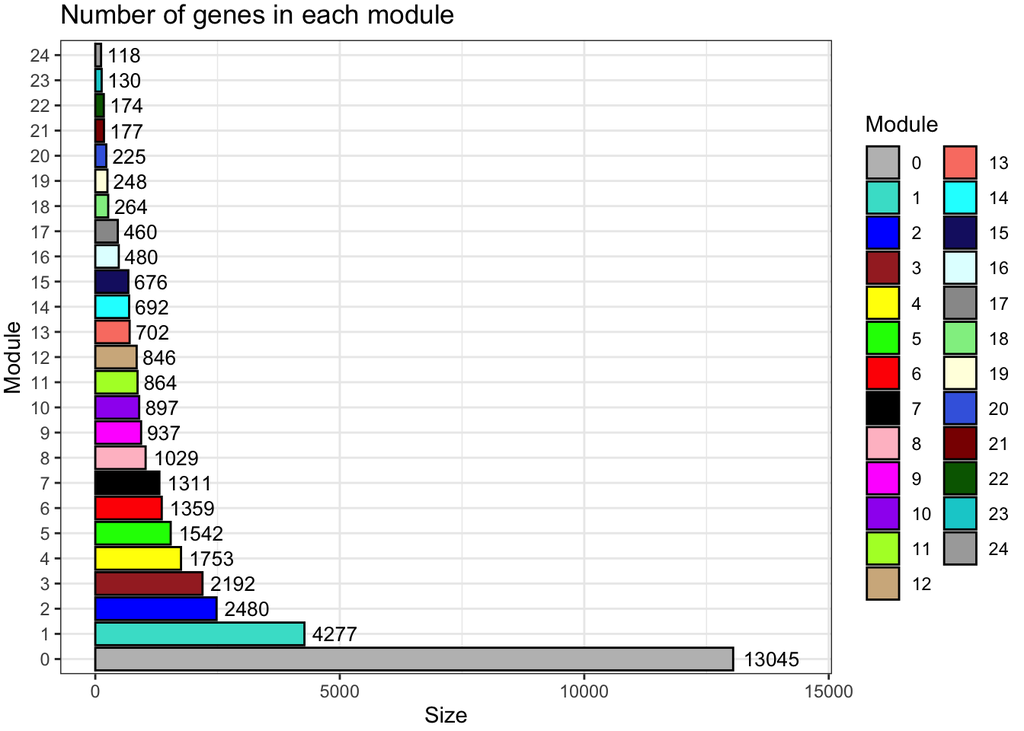

```r
# Convert labels to colors for plotting
merged_colors <- labels2colors(stage2results_X$modules$colors)
n_modules <- unique(merged_colors) %>% length()

samples_good <- sum(stage2results_X$modules$goodSamples) == length(stage2results_X$modules$goodSamples)
genes_good <- sum(stage2results_X$modules$goodGenes) == length(stage2results_X$modules$goodGenes)

ME_good <- sum(stage2results_X$modules$MEsOK) == length(stage2results_X$modules$MEsOK)
table(stage2results_X$modules$colors) %>%
  as.data.frame() %>%
  dplyr::rename(Module = Var1, Size = Freq) %>%
  dplyr::mutate(Module_color = labels2colors(as.numeric(as.character(Module)))) -> module_size

module_size %>%
  ggplot(aes(x = Module, y = Size, fill = Module)) +
  geom_col(color =  "#000000") +
  ggtitle("Number of genes in each module") +
  theme(legend.position = "none") +
  scale_fill_manual(values = setNames(module_size$Module_color,module_size$Module)) +
  geom_text(aes(label = Size),vjust = 0.5, hjust = -0.18, size = 3.5) +
  ylim(0, max(module_size$Size)*1.1) + theme_bw() +
  theme(plot.margin = margin(2, 2, 2, 2, "pt")) +
  coord_flip()-> module_size_barplot

module_size_barplot
```

```r
MEs <- stage2results_X$modules$MEs
# Module correlation to other modules
MEs_R <- bicor(MEs, MEs, maxPOutliers = 0.05)

idx.r <- which(rownames(MEs_R) == "ME0")
idx.c <- which(colnames(MEs_R) == "ME0")
MEs_R_noME0 <- MEs_R[-idx.r, -idx.c]

MEs_R_noME0[upper.tri(MEs_R_noME0)] %>%
  as.data.frame() %>%
  dplyr::rename("correlation" = ".") %>%
  ggplot(aes(correlation)) +
  geom_histogram(bins = 20) +
  #geom_density() +
  xlim(-1, 1) +
  ggtitle(paste0(prefix,"ME correlation\n w/o ",prefix ,"ME0")) -> MEs_R_density

pheatmap::pheatmap(MEs_R_noME0, color = colorRampPalette(c("Blue", "White", "Red"))(100),
                   silent = T,
                   breaks = seq(-1,1,length.out = 101),
                   treeheight_row = 10,
                   treeheight_col = 10,
                   main = paste0(prefix,"ME correlation heatmap w/o ", prefix ,"ME0"),
                   labels_row = rep("", length(rownames(MEs_R))), #paste0(prefix, rownames(MEs_R)),
                   labels_col = rep("", length(colnames(MEs_R))) #paste0(prefix, colnames(MEs_R))
) -> MEs_R_Corr

cowplot::plot_grid(MEs_R_density, MEs_R_Corr$gtable, labels = c("D", "E"), label_size = plot_labeling_size, rel_widths = c(0.6, 1)) -> density_eigen

all(rownames(omics_data_host) == rownames(MEs))
```

```
## [1] TRUE
```

```r
dim(omics_data_host) %>% paste0(c(" samples", " genes"))
```

```
## [1] "142 samples" "36878 genes"
```

```r
kME <- bicor(omics_data_host, MEs, maxPOutliers = 0.05)
dim(kME) %>% paste0(c(" genes", " modules"))
```

```
## [1] "36878 genes" "25 modules"
```

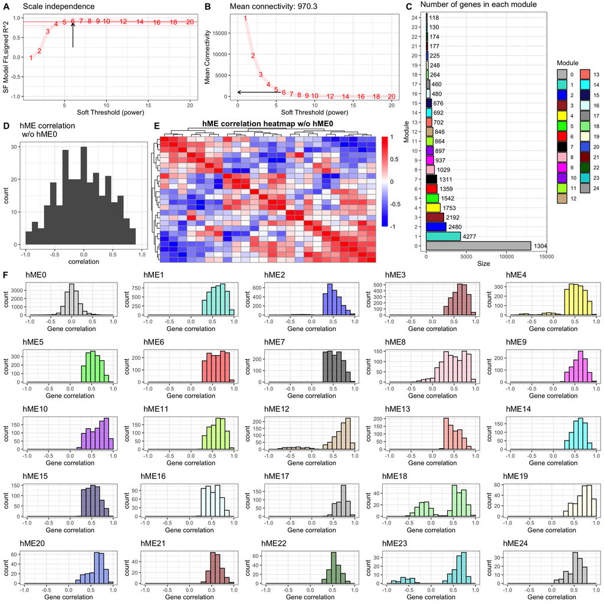

```r
# Corr within modules
corr_within_module <- function(omics_data_host, modules, module_x = 1){
  idx.omics_data_host <- which(modules$colors == module_x)
  idx.me <- which(colnames(modules$MEs) == paste0("ME",module_x))
  kME_x <- bicor(omics_data_host[,idx.omics_data_host], modules$MEs[,idx.me], maxPOutliers = 0.05)
  kME_x
}

ggplot.list <- list()

modules <-
  colnames(stage2results_X$modules$MEs)[colnames(stage2results_X$modules$MEs) %>% sub("ME", "", .) %>% as.numeric() %>% order()]

for(m in colnames(stage2results_X$modules$MEs)){
  h <- as.numeric(sub("ME","", m))
  data.frame(x = suppressWarnings(corr_within_module(omics_data_host = omics_data_host, modules = stage2results_X$modules, module_x = h))) %>%
    ggplot() +
    #geom_density(aes(x = x), fill = labels2colors(h), color = "black", alpha = 0.5) +
    geom_histogram(aes(x), fill = labels2colors(h), color = "black", alpha = 0.5, bins = 20) +
    xlim(-1, 1) +
    xlab("Gene correlation") +
    ggtitle(paste0(prefix,m)) -> da_plot

  ggplot.list[[m]] <- da_plot
}
ggplot.list <- ggplot.list[ggplot.list %>% names() %>% sub("ME", "", .) %>% as.numeric() %>% order()]
cowplot::plot_grid(plotlist = ggplot.list) -> density_all_plot

# comine to one plot
cowplot::plot_grid(si_mc_plot , density_eigen, ncol = 1, rel_heights = c(0.8,1)) -> part_1
cowplot::plot_grid(part_1, module_size_barplot, labels = c("", "C"), label_size = plot_labeling_size, rel_widths = c(1,0.5)) -> part_2
cowplot::plot_grid(part_2, density_all_plot, ncol = 1, rel_heights = c(0.8,1), labels = c("", "F"), label_size = plot_labeling_size) -> part_3
part_3
```

This code takes the results of a omics data and extracts the “hubs”, or most highly connected genes in the network, for each module.

```r
stage2results_X$hubs %>%
  as.data.frame() %>%
  dplyr::rename("gene_id" = ".") %>%
  tibble::rownames_to_column(var = "Module") -> top_genes

DT::datatable(top_genes)
```

|  | Module | gene_id |
| --- | --- | --- |
| 1 | 1 | ENSSSAG00000070249 |
| 2 | 2 | ENSSSAG00000108555 |
| 3 | 3 | ENSSSAG00000041313 |
| 4 | 4 | ENSSSAG00000086162 |
| 5 | 5 | ENSSSAG00000066721 |
| 6 | 6 | ENSSSAG00000046858 |
| 7 | 7 | ENSSSAG00000071444 |
| 8 | 8 | ENSSSAG00000061178 |
| 9 | 9 | ENSSSAG00000120479 |
| 10 | 10 | ENSSSAG00000080419 |

[output cut: 14 more lines]

### Statistical analysis

Linear regression analysis on the module eigengenes (principal components) from omics data, using the limma package. The sample information is loaded and the factors ‘Time’, ‘New_Diet’, and ‘Day’ are created based on the sample IDs. The design matrix for the regression is created using the ‘Day’ factor, and a linear model fit is performed on the transposed module eigengenes. The regression results are then run through an empirical Bayesian analysis. The topTable function is used to extract the regression statistics and create a data frame with the module names as the row names.

```r
#modules.omics_X.backup <- modules.omics_X
module_eigengenes <- modules.omics_X$MEs
all.equal(sample_info$ID_New, rownames(module_eigengenes))
```

```
## [1] TRUE
```

```r
sample_info %>%
  mutate(Time = factor(Time)) %>%
  mutate(New_Diet = factor(New_Diet)) %>%
  mutate(Day = ifelse(Time == "T1", paste0("T1_", New_Diet),
                      ifelse(Time == "T2", paste0("T2_", New_Diet), paste0("T3_", New_Diet)))) -> meta
DT::datatable(meta)
```

|  | Time | Diet | New_Diet | Tank_number | Sample_Type | Sample_Number | ID | BW | Length | Sex | Gut_struc | Gut_light | Anus_bleed | Gut_bleed | Fat_Score | Heart_Sco | softliver | patchy_liver | Liver_Sco | HSI | CSI | ID_New | common | Day |
| --- | --- | --- | --- | --- | --- | --- | --- | --- | --- | --- | --- | --- | --- | --- | --- | --- | --- | --- | --- | --- | --- | --- | --- | --- |
| T1_CTR_tk1_01 | T1 | CTR | CTR | tk1 | Hind_Gut | 1 | T1_CTR_tk1_1 | 85.8 | 19 | 0 | 0 | 1 | 0 | 0 | 3 | 0 | 0 | 0 | 3 | 1.282051282 |  | T1_CTR_tk1_01 | T1_CTR_tk1_01 | T1_CTR |
| T1_CTR_tk1_03 | T1 | CTR | CTR | tk1 | Hind_Gut | 3 | T1_CTR_tk1_3 | 83.51 | 18.4 | 1 | 1 | 1 |  | 0 | 2 | 0 | 0 | 0 | 3 | 1.508801341 | 0.126930906 | T1_CTR_tk1_03 | T1_CTR_tk1_03 | T1_CTR |
| T2_CTR_tk1_01 | T2 | CTR | CTR | tk1 | Hind_Gut | 1 | T2_CTR_tk1_1 | 152 | 23.7 | 1 | 0 | 1 |  | 0 | 3.5 | 0 | 0 | 0 | 4 |  | 0.130263158 | T2_CTR_tk1_01 | T2_CTR_tk1_01 | T2_CTR |
| T3_CTR_tk2_01 | T3 | CTR | CTR | tk2 | Hind_Gut | 1 | T3_CTR_tk2_1 | 300 | 28.2 | 0 | 0 | 1 | 1 | 0 | 2 | 0 | 0 | 0 | 2 | 1.433333333 | 0.148 | T3_CTR_tk2_01 | T3_CTR_tk2_01 | T3_CTR |
| T1_CTR_tk1_05 | T1 | CTR | CTR | tk1 | Hind_Gut | 5 | T1_CTR_tk1_5 | 82.42 | 18 | 1 | 0 | 1 |  | 0 | 2 | 0 | 0 | 0 | 2 | 1.455957292 |  | T1_CTR_tk1_05 | T1_CTR_tk1_05 | T1_CTR |
| T1_CTR_tk1_07 | T1 | CTR | CTR | tk1 | Hind_Gut | 7 | T1_CTR_tk1_7 | 95.39 | 19.3 | 0 | 0 | 1 |  | 0 | 2 | 0 | 0 | 0 | 2 | 1.467659084 | 0.12055771 | T1_CTR_tk1_07 | T1_CTR_tk1_07 | T1_CTR |
| T3_CTR_tk3_01 | T3 | CTR | CTR | tk3 | Hind_Gut | 1 | T3_CTR_tk3_1 | 190 | 24.9 | 0 | 0 | 1 |  | 0 | 1 | 0 | 0 | 0 | 1 | 1.684210526 | 0.164736842 | T3_CTR_tk3_01 | T3_CTR_tk3_01 | T3_CTR |
| T3_CTR_tk1_01 | T3 | CTR | CTR | tk1 | Hind_Gut | 1 | T3_CTR_tk1_1 | 156 | 23.6 | 0 | 0 | 1 | 0 | 0 | 1.5 | 0.5 | 0 | 0 | 2 | 1.666666667 | 0.202564103 | T3_CTR_tk1_01 | T3_CTR_tk1_01 | T3_CTR |
| T3_CTR_tk1_03 | T3 | CTR | CTR | tk1 | Hind_Gut | 3 | T3_CTR_tk1_3 | 236 | 27 | 1 | 0 | 1 | 0 | 0 |  | 0.5 | 1 | 0 | 1.5 | 1.652542373 | 0.144491525 | T3_CTR_tk1_03 | T3_CTR_tk1_03 | T3_CTR |
| T3_CTR_tk3_03 | T3 | CTR | CTR | tk3 | Hind_Gut | 3 | T3_CTR_tk3_3 | 281 | 27.8 | 1 | 0 | 1 |  | 0 | 1 | 0 | 1 | 1 | 2 | 1.423487544 | 0.088967972 | T3_CTR_tk3_03 | T3_CTR_tk3_03 | T3_CTR |

[output cut: 132 more lines]

```r
des_mat <- model.matrix(~ meta$Day)
fit <- limma::lmFit(t(module_eigengenes), design = des_mat)
fit <- limma::eBayes(fit)

stats_df <- limma::topTable(fit, number = ncol(module_eigengenes)) %>%
  tibble::rownames_to_column("module")

DT::datatable(stats_df)
```

|  | module | meta.DayT1_MC1 | meta.DayT1_MC2 | meta.DayT1_MN3 | meta.DayT2_CTR | meta.DayT2_MC1 | meta.DayT2_MC2 | meta.DayT2_MN3 | meta.DayT3_CTR | meta.DayT3_MC1 | meta.DayT3_MC2 | meta.DayT3_MN3 | AveExpr | F | P.Value | adj.P.Val |
| --- | --- | --- | --- | --- | --- | --- | --- | --- | --- | --- | --- | --- | --- | --- | --- | --- |
| 1 | ME18 | -0.00232521593375002 | 0.00665544025395498 | -0.00354158094981589 | 0.15721602065705 | 0.149776546590945 | 0.141424915106842 | 0.154136713669553 | 0.173117876836016 | 0.1762734989785 | 0.172500144577062 | 0.185163281661911 | -7.37410181821479e-18 | 71.5917022699037 | 6.2069289772321e-51 | 1.55173224430802e-49 |
| 2 | ME23 | 0.0251464425049631 | 0.011180591644896 | 0.00917610381622785 | -0.166776345544469 | -0.176105443113575 | -0.159045741918063 | -0.174433456824908 | -0.11447709045556 | -0.120196572994577 | -0.138901100883323 | -0.127106765952084 | -7.9635413091717e-18 | 64.192274886589 | 3.02264820154685e-48 | 3.77831025193356e-47 |
| 3 | ME21 | 0.0170757373892214 | -0.00683679461859791 | 0.0454489788430434 | -0.107480456310833 | -0.118372096902803 | -0.132214429432738 | -0.124799307533126 | -0.156602290742071 | -0.130482548032107 | -0.178798257127303 | -0.160426101761128 | 9.05308814025396e-18 | 47.529322181759 | 4.08457614073919e-41 | 3.40381345061599e-40 |
| 4 | ME9 | 0.0168711659370387 | 0.0303792123984143 | 0.0307446623658998 | 0.0150737573498576 | 0.0190603309942828 | -0.00305979992289531 | -0.0207555780265302 | -0.14060439218885 | -0.131173663030305 | -0.157561776713683 | -0.143587759204743 | 3.13807811895452e-18 | 40.7285904582866 | 1.25819659106895e-37 | 7.86372869418095e-37 |
| 5 | ME22 | 0.00950911568376627 | 0.00827211191102577 | 0.0181980954722725 | 0.130979454797363 | 0.143376830576072 | 0.102068812522009 | 0.106801684851521 | -0.0588285636416852 | -0.0475035010710313 | -0.0535835542861506 | -0.0545895408838517 | 3.32437764718443e-18 | 35.1931501349094 | 1.89370846853435e-34 | 9.46854234267177e-34 |
| 6 | ME7 | -0.0084341618401846 | 0.00567221590150217 | 0.0338415283592042 | -0.0622655105507397 | -0.0479669417672438 | -0.0459716305770972 | -0.0651002001685961 | -0.159033594190728 | -0.151491812775619 | -0.177527604802117 | -0.165042666831036 | -1.16605180128159e-17 | 31.2088717733777 | 6.23505167822893e-32 | 2.59793819926205e-31 |
| 7 | ME5 | 0.00451737439594838 | -0.0124399716284468 | -0.0333529287942747 | 0.0292244724388559 | 0.0180880020509789 | 0.0309401934218727 | 0.0430043063789077 | 0.153067456466849 | 0.140854847963417 | 0.167640721250993 | 0.156919649503574 | 7.31912818693383e-18 | 29.6015741394737 | 7.47999851234198e-31 | 2.67142804012213e-30 |
| 8 | ME16 | -0.0282897132150793 | -0.00835876054894824 | 0.0067020165077783 | 0.0667262221601375 | 0.0935840064561216 | 0.0911233383107237 | 0.097793696567124 | 0.129871656157507 | 0.117771720118704 | 0.13454068314039 | 0.129179574416207 | 2.20016688748889e-17 | 10.8570355603721 | 3.52162041425161e-14 | 1.10050637945363e-13 |
| 9 | ME15 | 0.026233801962456 | 0.0266597305620818 | -0.00131738799408098 | -0.000680044660291976 | -0.0234439270567815 | -0.0252036840483941 | -0.0532619490924304 | -0.115954735266716 | -0.108195728921181 | -0.131626850989659 | -0.122917245431825 | -1.3124954468328e-18 | 10.5894126543421 | 7.30282302985816e-14 | 2.02856195273838e-13 |
| 10 | ME12 | -0.0227037390002919 | -0.020097947794757 | -0.0378525930268625 | -0.0628175644846296 | -0.0591192940316779 | -0.0141487325141192 | -0.0448767138585825 | 0.0823527814153013 | 0.0829947117923697 | 0.0792260635487726 | 0.0818365435219905 | -1.09764017124307e-17 | 9.86729042957559 | 5.4154848945236e-13 | 1.3538712236309e-12 |

[output cut: 15 more lines]

Let’s make plot of module 21

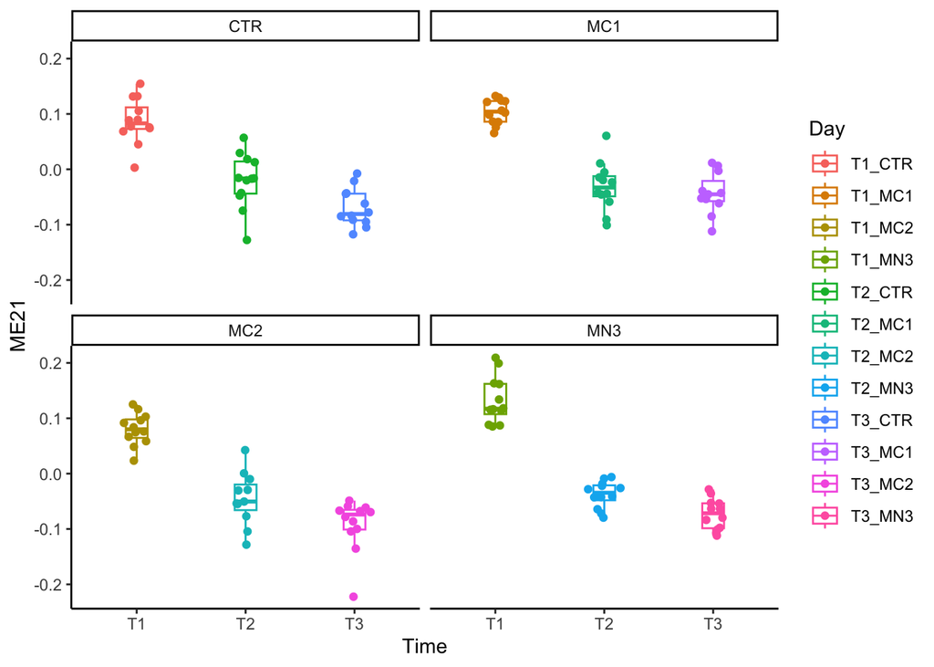

```r
module_df <- module_eigengenes %>%
  tibble::rownames_to_column("ID_New") %>%
  dplyr::inner_join(meta %>%
                      dplyr::select(ID_New, Day, Time, New_Diet),
                    by = c("ID_New" = "ID_New"))


ggplot(module_df, aes(x = Time, y = ME21, color = Day)) +
  geom_boxplot(width = 0.2, outlier.shape = NA) +
  ggforce::geom_sina(maxwidth = 0.3) +
  theme_classic() + facet_wrap("New_Diet")
```

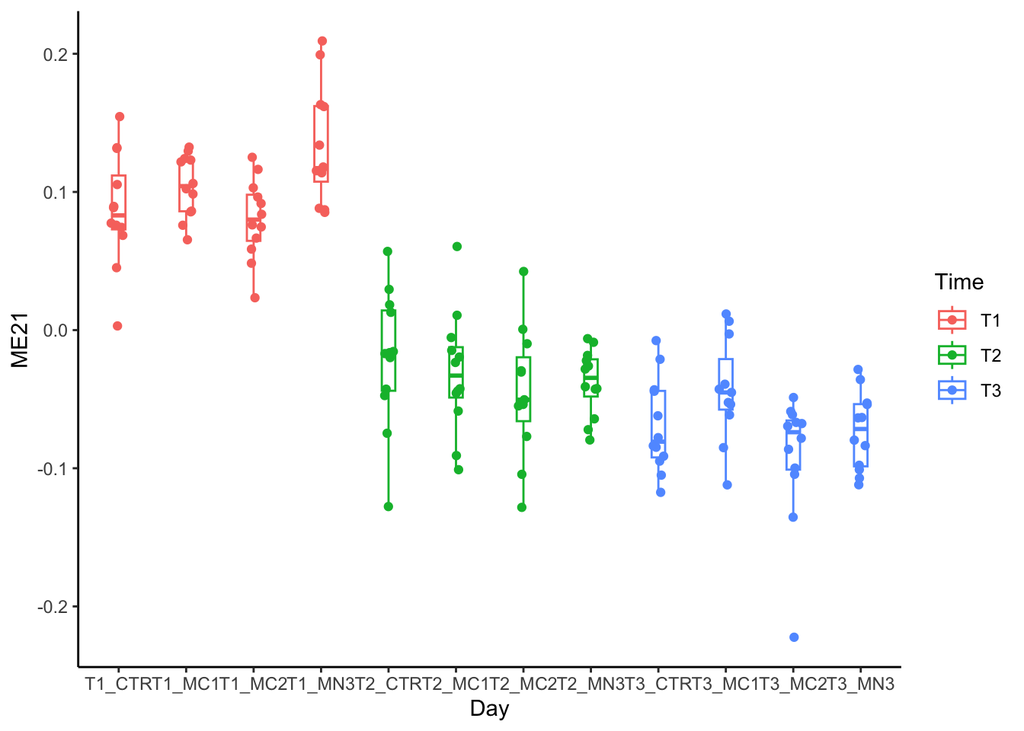

```r
ggplot(module_df, aes(x = Day, y = ME21, color = Time)) +
  geom_boxplot(width = 0.2, outlier.shape = NA) +
  ggforce::geom_sina(maxwidth = 0.3) +
  theme_classic()
```

What genes are a part of module 21?

```r
gene_module_key <- tibble::enframe(modules.omics_X$colors, name = "gene", value = "module") %>%
  # Let's add the `ME` part so its more clear what these numbers are and it matches elsewhere
  dplyr::mutate(module = paste0("ME", module))

# gene_module_key %>%
#   dplyr::filter(module == "ME21")
DT::datatable(gene_module_key)
```

|  | gene | module |
| --- | --- | --- |
| 1 | ENSSSAG00000004313 | ME0 |
| 2 | ENSSSAG00000047403 | ME2 |
| 3 | ENSSSAG00000121050 | ME0 |
| 4 | ENSSSAG00000100088 | ME0 |
| 5 | ENSSSAG00000116284 | ME0 |
| 6 | ENSSSAG00000047532 | ME0 |
| 7 | ENSSSAG00000102231 | ME2 |
| 8 | ENSSSAG00000103407 | ME0 |
| 9 | ENSSSAG00000047554 | ME0 |
| 10 | ENSSSAG00000047574 | ME0 |

[output cut: 36868 more lines]

### Functional analysis

The code in R connects to the AnnotationHub package and selects OrgDb annotations for the species “Salmo salar”. It creates two objects, SsalOrg, by subsetting and extracting the desired annotations from the ah object.

```r
# get OrgDb from AnnotationHub
ah <- AnnotationHub()
SsalOrg <- subset(ah, ah$species == "Salmo salar" & ah$rdataclass=="OrgDb")
SsalOrg <- ah[["AH96017"]]
```

This script performs gene enrichment analysis on multiple modules of genes. The modules of genes are generated from omics data, and the gene annotations are read from a csv file. The probes from the omics data are matched with the gene IDs from the annotations, and the LocusLink IDs are obtained. The unique modules are then selected, and their LocusLink IDs are written into separate text files. Finally, gene ontology (GO) and KEGG pathway analysis are performed for each module using the enrichGO and enrichKEGG functions, respectively. The results are then visualized using the dotplot function.

```r
moduleLabels <- modules.omics_X$colors
moduleColors <- labels2colors(modules.omics_X$colors)
table(moduleColors)
```

```
## moduleColors
##         black          blue         brown          cyan     darkgreen
##          1311          2480          2192           692           174
##      darkgrey       darkred darkturquoise         green   greenyellow
##           118           177           130          1542           864
##          grey        grey60     lightcyan    lightgreen   lightyellow
##         13045           460           480           264           248
##       magenta  midnightblue          pink        purple           red
##           937           676          1029           897          1359
##     royalblue        salmon           tan     turquoise        yellow
##           225           702           846          4277          1753
```

```r
# table(moduleLabels)
# table(moduleColors, moduleLabels)

MEs <- modules.omics_X$MEs
geneTree <- modules.omics_X$dendrograms[[1]]


#https://gitlab.com/garethgillard/ssalv3annotation
annot1 <- read.csv("/Users/shashankgupta/Desktop/ImprovAFish/github/ImprovaFish/Input/Salmo_salar-GCA_905237065.2_gene_annotations.csv", header = TRUE)

probes <- colnames(omics_data_host)
probes2annot <- match(probes, annot1$gene_id)
allLLIDs <- annot1$v2.gene_id.NCBI[probes2annot]

intModules <- unique(moduleColors)
dir.create("/Users/shashankgupta/Desktop/ImprovAFish/github/ImprovaFish/MetaTranscriptomics/intermediate_files")
setwd("/Users/shashankgupta/Desktop/ImprovAFish/github/ImprovaFish/MetaTranscriptomics/intermediate_files")
for (module in intModules)
{
  # Select module probes
  modGenes = (moduleColors==module)
  # Get their entrez ID codes
  modLLIDs = allLLIDs[modGenes]
  # Write them into a file
  fileName = paste("LocusLinkIDs-", module, ".txt", sep="");
  write.table(as.character(modLLIDs), file = fileName, row.names = FALSE, col.names = FALSE)
}

fileName = paste("LocusLinkIDs-all.txt", sep="");
write.table(as.character(allLLIDs), file = fileName, row.names = FALSE, col.names = FALSE)

#table(moduleColors)
list_names <- unique(moduleColors)
all.df <- read.table("LocusLinkIDs-all.txt")
all.df$V1 <- as.character(all.df$V1)
for (i in list_names){
  assign(paste(i,"_df", sep=""), read.table(paste0("LocusLinkIDs-",i,".txt")))
  assign(paste("resGO_",i, sep=""), enrichGO(gene = get(paste0(i,"_df"))$V1, ont = "BP", universe = all.df$V1, OrgDb = "SsalOrg", pvalueCutoff  = 0.05,qvalueCutoff  = 0.05))
  assign(paste("resGO_dotplot_",i, sep=""), dotplot(get(paste0("resGO_",i))))
  assign(paste("resKEGG_",i, sep=""), enrichKEGG(gene = get(paste0(i,"_df"))$V1, universe = all.df$V1,  organism = "sasa", pvalueCutoff = 0.05, qvalueCutoff  = 0.05))
  assign(paste("resKEGG_dotplot_",i, sep=""), dotplot(get(paste0("resKEGG_",i))))
}
```

```r
# save all the plots
setwd("/Users/shashankgupta/Desktop/ImprovAFish/github/ImprovaFish/MetaTranscriptomics/intermediate_files")
resGO_dot_plots <- ls(pattern="resGO_dotplot_*")

# saving PNG
for (i in 1:length(resGO_dot_plots)) {
  tryCatch({
    png(paste0(resGO_dot_plots[i], ".png"))
    print(get(resGO_dot_plots[i]))
    dev.off()
  }, error = function(e) {
    print(paste("Error printing", resGO_dot_plots[i], ":", e))
    file.remove(paste0(resGO_dot_plots[i], ".png"))
  })
}
```

```
## [1] "Error printing resGO_dotplot_darkturquoise : Error in ans[ypos] <- rep(yes, length.out = len)[ypos]: replacement has length zero\n"
```

```
## [1] "Error printing resGO_dotplot_greenyellow : Error in ans[ypos] <- rep(yes, length.out = len)[ypos]: replacement has length zero\n"
```

```
## [1] "Error printing resGO_dotplot_grey60 : Error in ans[ypos] <- rep(yes, length.out = len)[ypos]: replacement has length zero\n"
```

```
## [1] "Error printing resGO_dotplot_lightcyan : Error in ans[ypos] <- rep(yes, length.out = len)[ypos]: replacement has length zero\n"
```

```
## [1] "Error printing resGO_dotplot_lightgreen : Error in ans[ypos] <- rep(yes, length.out = len)[ypos]: replacement has length zero\n"
```

```
## [1] "Error printing resGO_dotplot_midnightblue : Error in ans[ypos] <- rep(yes, length.out = len)[ypos]: replacement has length zero\n"
```

```r
resKEGG_dot_plots <- ls(pattern="resKEGG_dotplot_*")

# saving PNG
for (i in 1:length(resKEGG_dot_plots)) {
  tryCatch({
    png(paste0(resKEGG_dot_plots[i], ".png"))
    print(get(resKEGG_dot_plots[i]))
    dev.off()
  }, error = function(e) {
    print(paste("Error printing", resKEGG_dot_plots[i], ":", e))
    file.remove(paste0(resKEGG_dot_plots[i], ".png"))
  })
}
```

```
## [1] "Error printing resKEGG_dotplot_darkgrey : Error in ans[ypos] <- rep(yes, length.out = len)[ypos]: replacement has length zero\n"
```

```
## [1] "Error printing resKEGG_dotplot_darkturquoise : Error in ans[ypos] <- rep(yes, length.out = len)[ypos]: replacement has length zero\n"
```

```
## [1] "Error printing resKEGG_dotplot_lightcyan : Error in ans[ypos] <- rep(yes, length.out = len)[ypos]: replacement has length zero\n"
```

```
## [1] "Error printing resKEGG_dotplot_lightgreen : Error in ans[ypos] <- rep(yes, length.out = len)[ypos]: replacement has length zero\n"
```